# The Study of ‘Other’: How Athletes and Students of Different Ethnicities Perform Academically at Williams

Haoyu Sheng

December 7, 2017

# Motivation and Approaches

- **Motivation**
  - Informal Response to the article : *What Does it Mean to be the Best?: An Alum Considers the Relative Importance of Admission Criteria*
  - Personal Interest in seeing how students of Asian origins are performing academically
- **Approach**
  - Attain information from graduation catalog and team rosters
  - Use the `wru` package to identify someone’s ethnicity through surname analysis
  - Compare the percentage of students attaining `cum laude` among different demographics.

# Disclaimers and Limitations

- Limitations of the Bayesian surname analysis. Inability to account for names such as “Lee”
- Loss of information during transition. For example: a student named Andrew might be recorded as Andy on the team roster
- Inability to account for walk-ons.
- Graduation honors are not the only metrics for a student’s importance and contribution to the college!

# Data

- Utilizes two datasets: **student** and **roster**
- The `students` dataset comes from the Williams College catalog archive, containing graduation data from the class of 2003 to the class of 2015
- Has 6800 entries

  | name | year |
  | --- | --- |
  | *Amy Eph, with highest honor in Economics | 2003 |
  | *Chris Somebody | 2003 |
  | *Lauren Nobody | 2003 |

- The `roster` dataset comes forom Williams College athletic archives, including rosters from the class of 2002 to the class of 2015 and teams such as soccer, football, and cross country
- Has 1549 entries

  | name | year | team |
  | --- | --- | --- |
  | John Lax | 2013 | Men’s Lacrosse |
  | Ryan Tennis | 2015 | Men’s Lacrosse |
  | Will Football | 2015 | Men’s Lacrosse |

# Data Tidying and Manuvering

- Join the two initial dataframes
- Read honors based on the names
- Analyze ethnicities based on surnames
- summarize ratio for each subgroup for each year

- | year | ratio | race |
  | --- | --- | --- |
  | 2003 | 0.3665158 | other |
  | 2003 | 0.2500000 | hispanic |
  | 2003 | 0.2391304 | asian |

- A graphical summary of the data

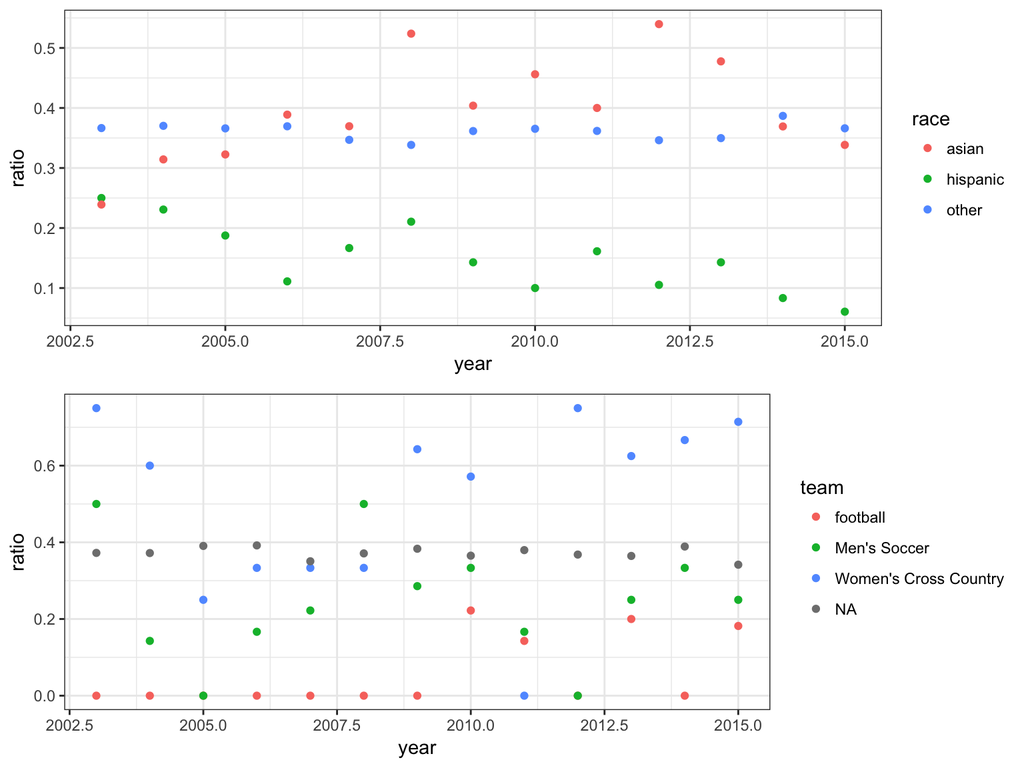

# Two proportion z-test

```r
hispanic <- classified %>% filter(hispanic == 1) %>% group_by(latin) %>% summarize(value = length(name))
non_hispanic = classified %>% filter(hispanic == 0) %>% group_by(latin) %>%
    summarize(value = length(name))
prop.test(c(filter(hispanic, latin == 1)$value, filter(non_hispanic, latin ==
    1)$value), c(sum(hispanic$value), sum(non_hispanic$value)))
```

```
##
##  2-sample test for equality of proportions with continuity
##  correction
##
## data:  c(filter(hispanic, latin == 1)$value, filter(non_hispanic, latin ==  out of c(sum(hispanic$value), sum(non_hispanic$value))    1)$value) out of c(sum(hispanic$value), sum(non_hispanic$value))
## X-squared = 73.522, df = 1, p-value < 2.2e-16
## alternative hypothesis: two.sided
## 95 percent confidence interval:
##  -0.2635428 -0.1848569
## sample estimates:
##    prop 1    prop 2
## 0.1400560 0.3642558
```

- Independence
- Success/Failure Condition
- 10% Condition

# T tests

```r
athlete <- athletic_summary %>% filter(athlete == 1)
non_athlete <- athletic_summary %>% filter(athlete == 0)
t.test(athlete$ratio, non_athlete$ratio)
```

```
##
##  Welch Two Sample t-test
##
## data:  athlete$ratio and non_athlete$ratio
## t = -7.376, df = 13.891, p-value = 3.643e-06
## alternative hypothesis: true difference in means is not equal to 0
## 95 percent confidence interval:
##  -0.14665658 -0.08054325
## sample estimates:
## mean of x mean of y
## 0.2586998 0.3722997
```

- Conditions
- Nearly Normal:

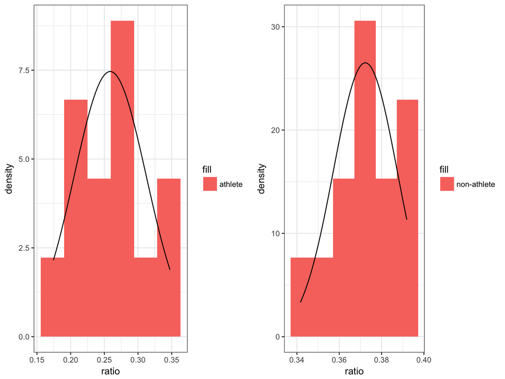

- Independence

# Thoughts and Potential Future Work

- Different subgroups of students might have different focuses
- Interesting data for the Davis center
- A foundation for a study on the relationship between socioeconomic status and thriving academically at college
- Compare results across colleges to examine if our institution is doing its best to support students of various demographics